# Caractéristiques générales et logiques d’implantation des surfaces élémentaires de plans d’eau de la zone d’étude

##### Superficie des surfaces élémentaires de plans d’eau en fonction du ratio de débit

Surface moyenne :

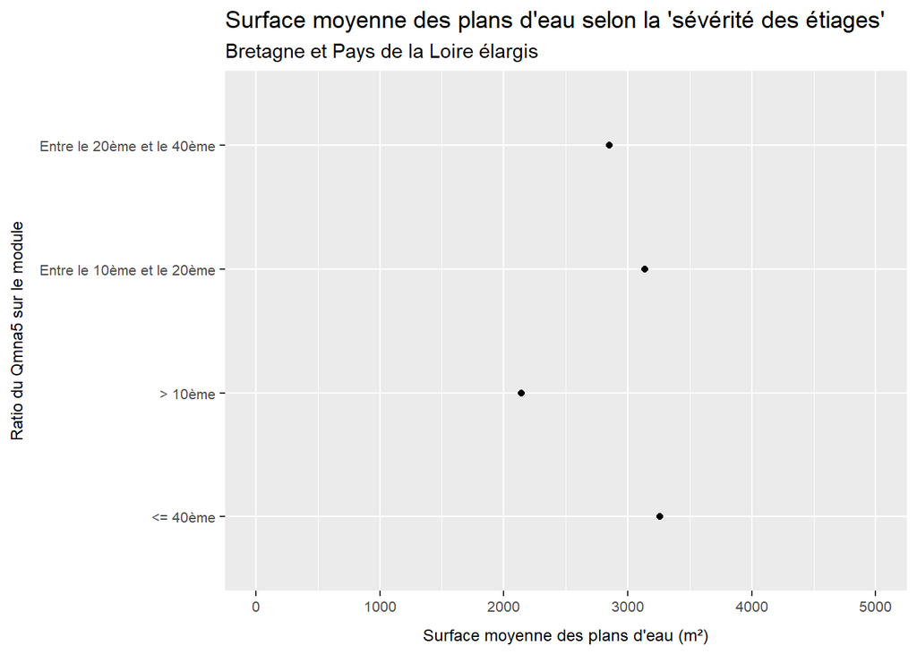

Sans les mares et marais :

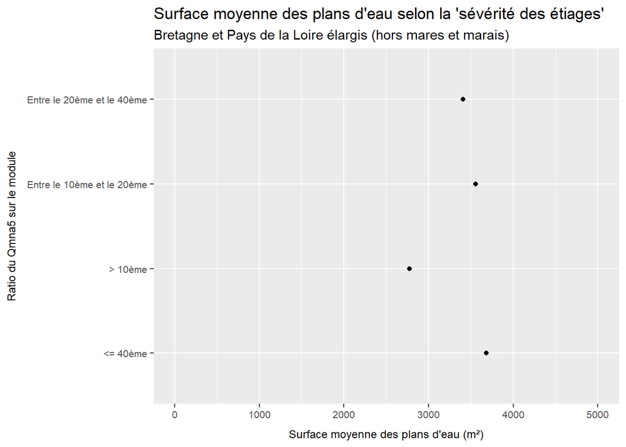

Surface médiane :

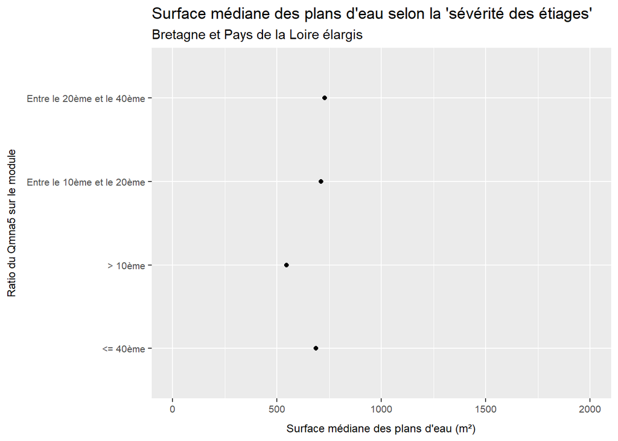

Sans les mares et marais:

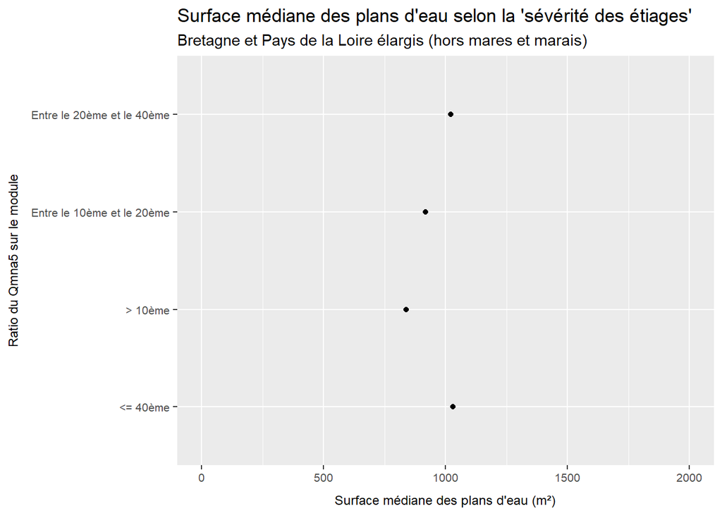

#### L’implantation des plans d’eau est-elle liée au type de masse d’eau (densité plus forte en zone côtière et littorale) ?

##### Type de masses d’eau de la zone d’étude

[figure not shown]

Sont écartées de cette hypothèse les masses d’eau plan d’eau.

| Type de masse d’eau | Surface (km²) | Proportion de surface (%) | Surface de marais retenue (km²) | Nombre total de plans d’eau | Densité numérique en plans d’eau par km² | Nombre de plans d’eau hors mares et marais | Densité numérique en plans d’eau hors mares et marais par km² |
| --- | --- | --- | --- | --- | --- | --- | --- |
| cotiere | 2506 | 3.5 | 179 | 13439 | 5.36 | 3719 | 1.60 |
| cours deau | 67760 | 93.6 | 1030 | 185391 | 2.74 | 134120 | 2.01 |
| transition | 2110 | 2.9 | 270 | 6330 | 3.00 | 3506 | 1.91 |

#### Densités de plans d’eau en fonction du type de masses d’eau

Nous avons ici étudié les densité de plans d’eau en fonction des types de masses d’eau :

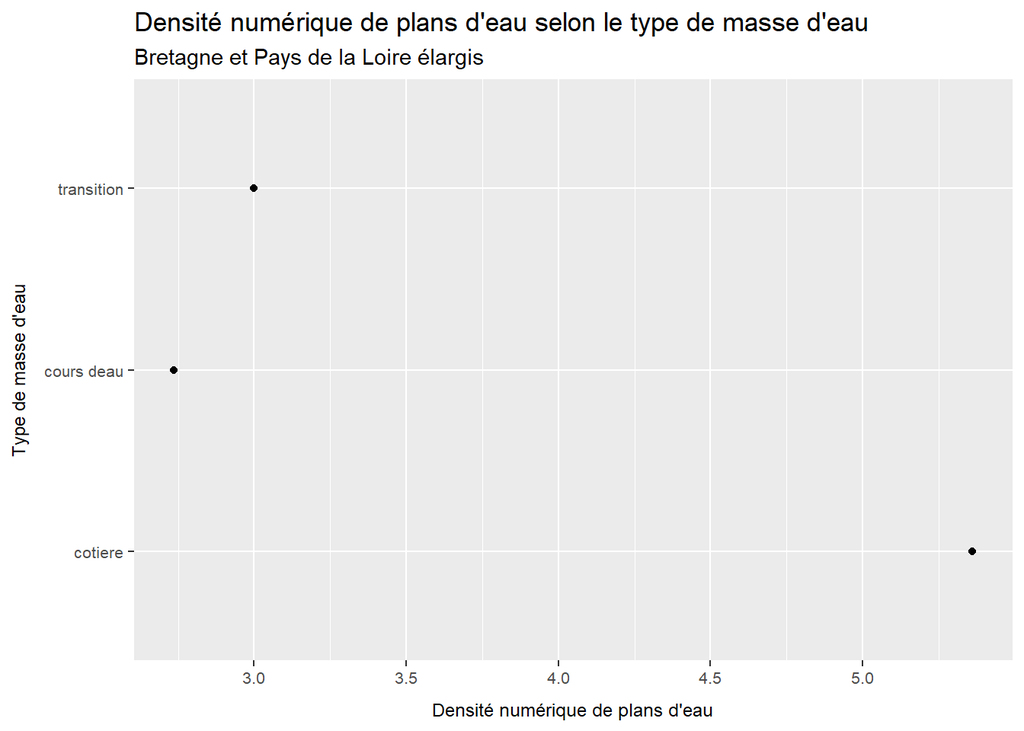

En limitant aux plans d’eau hors mares et marais :

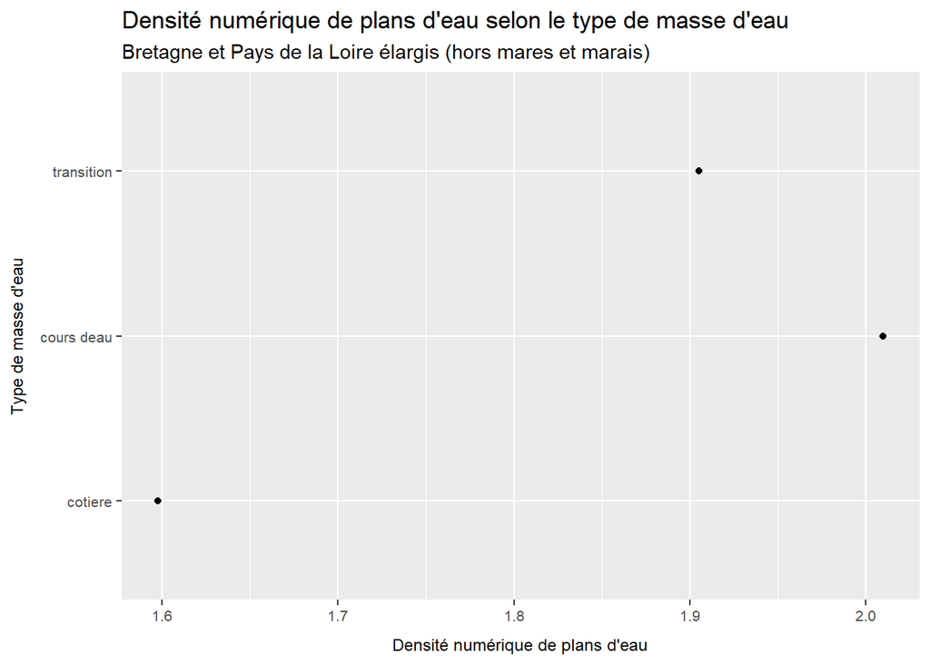

On relève ici encore l’influence des secteurs de marais en zone côtière. L’analyse de la densité numérique de plans d’eau en fonction du type de masse d’eau, en l’absence des mares et des marais, indique qu’il y a relativement plus de plans d’eau en masses d’eau “Cours d’eau” qu’en masses d’eau “Côtières” ou de transition.

#### L’implantation des plans d’eau est-elle liée aux Hydro Eco Régions (HER) ?

##### Les HER de niveau 2 de la zone d’étude

[figure not shown]

| Nom de la HER | Surface (km²) | Proportion de surface (%) | Surface de marais retenue (km²) | Nombre total de plans d’eau | Densité numérique en plans d’eau par km² | Nombre de plans d’eau hors mares et marais | Densité numérique en plans d’eau hors mares et marais par km² |
| --- | --- | --- | --- | --- | --- | --- | --- |
| Sologne-Foret d’Orleans | 5 | 0.0 | 0 | 13 | 2.38 | 8 | 1.47 |
| TC-aureole cretace | 2182 | 3.0 | 0 | 1557 | 0.71 | 1160 | 0.53 |
| Tables calcaires Sud Loire | 1229 | 1.7 | 0 | 1671 | 1.36 | 1288 | 1.05 |
| TC-Nord Loire-Perche | 13883 | 18.9 | 0 | 40146 | 2.89 | 27821 | 2.00 |
| MA-nord est | 6394 | 8.7 | 45 | 14063 | 2.20 | 11479 | 1.81 |
| MA-sud interieur | 17301 | 23.6 | 845 | 86809 | 5.02 | 52132 | 3.17 |
| MA-ouest | 13245 | 18.1 | 0 | 15231 | 1.15 | 13217 | 1.00 |
| TC - Charentes Poitou | 1965 | 2.7 | 459 | 4119 | 2.10 | 1427 | 0.95 |
| MA-est interieur | 12374 | 16.9 | 0 | 34885 | 2.82 | 28280 | 2.29 |
| MA-cotes du nord | 4725 | 6.4 | 130 | 8137 | 1.72 | 6954 | 1.51 |

#### Densités de plans d’eau en fonction des hydro éco régions

Nous avons ici étudié les densité de plans d’eau en fonction des HER :

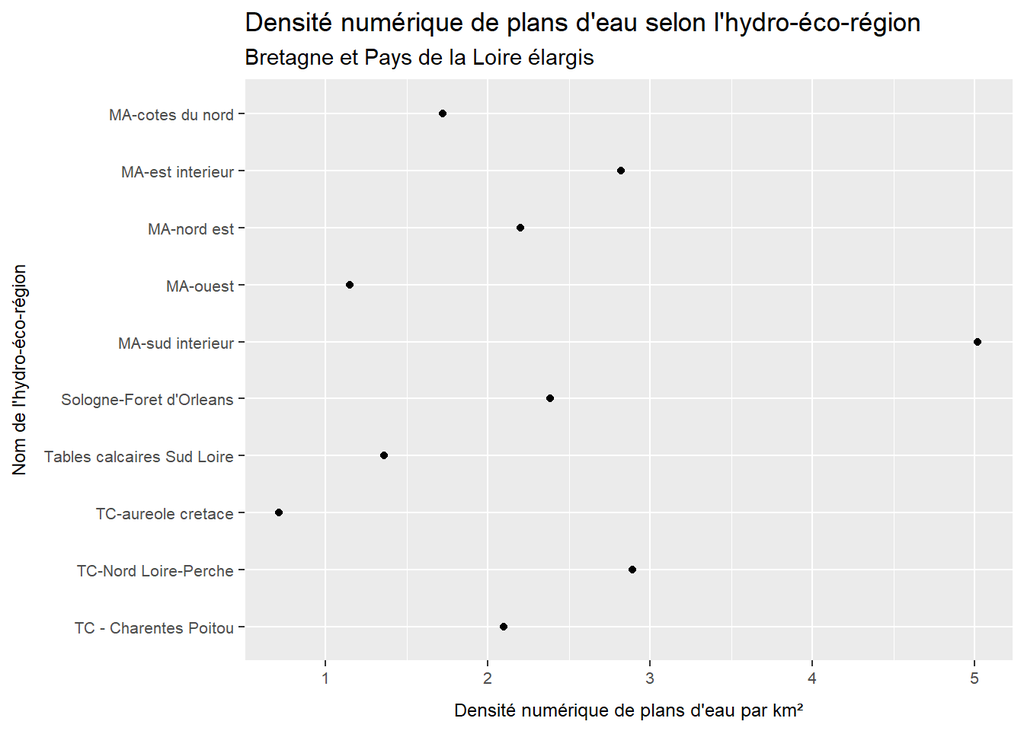

En limitant aux plans d’eau hors mares et marais :

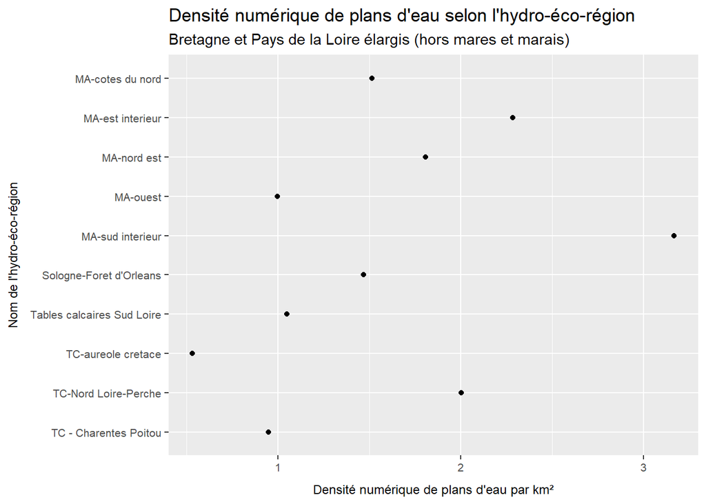

Et les densités surfaciques :

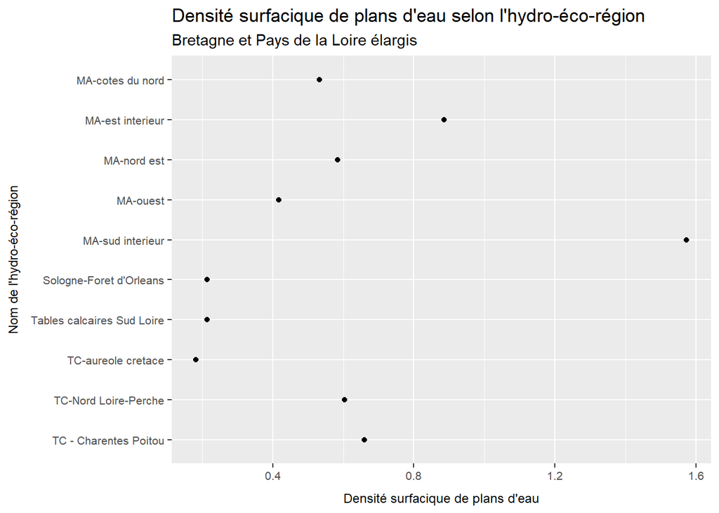

En limitant aux plans d’eau hors mares et marais :

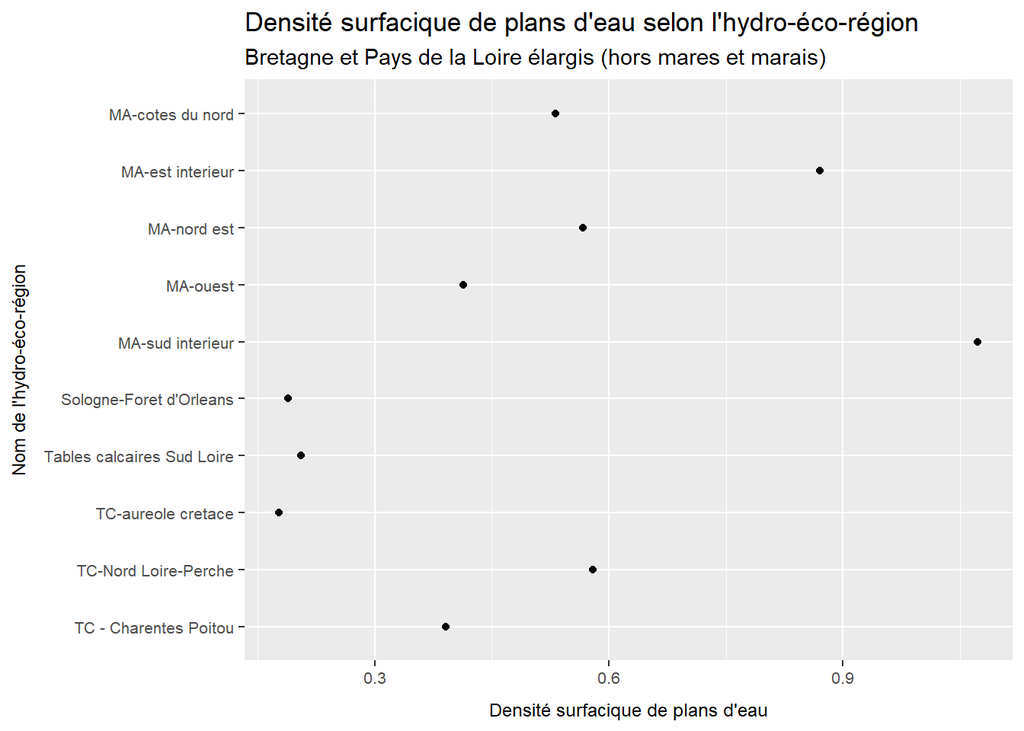

[figure not shown]